# Lecture 6: Quality Control & Alignment Basics

06/04/2020

### Goals

- Understanding computational context of RNA-Seq

### Goals

- Understanding computational context of RNA-Seq
- Learning to judge data for quality metrics of RNA-Seq

### Common RNA-Seq Computational Processing

- Alignment
  - *Tools Like:*
  - STAR - [github](https://github.com/alexdobin/STAR)
  - HISAT2 - [link](http://daehwankimlab.github.io/hisat2/)
  - Bowtie 2 - [link](http://bowtie-bio.sourceforge.net/bowtie2/index.shtml)

### Common RNA-Seq Computational Processing

- Alignment
- Mapping
  - *Tools Like:*
  - Salmon - [documentation](https://salmon.readthedocs.io/en/latest/index.html)
  - Kallisto - [documentation](https://pachterlab.github.io/kallisto/starting)

### Common RNA-Seq Computational Processing

- Alignment
- Mapping
- Counting
  - *Tools Like:*
  - featureCounts - [documentation](http://bioinf.wehi.edu.au/featureCounts/)
  - HTSeq - [documentation](https://htseq.readthedocs.io/en/master/)

### Alignment

- Requires a genome `.fasta` file & preferably a `.gtf` file containing a comprehensive set of genes
  - These produce an index
- Requires reads in the form of `.fastq`
- Outputs a `.bam`/`.sam` file indicating where reads are mapped in the genome.
- To be followed up likely by a quantification step.

### Alignment

- Input can be single end or paired end reads.

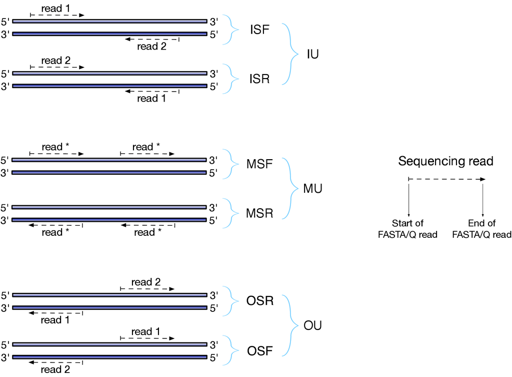

### Alignment

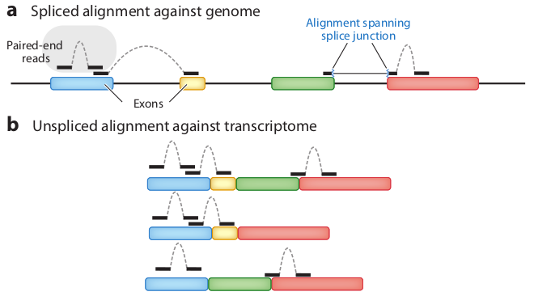

### Alignment

- Alignment to the genome
  - STAR does this, also HISAT2 and Bowtie2

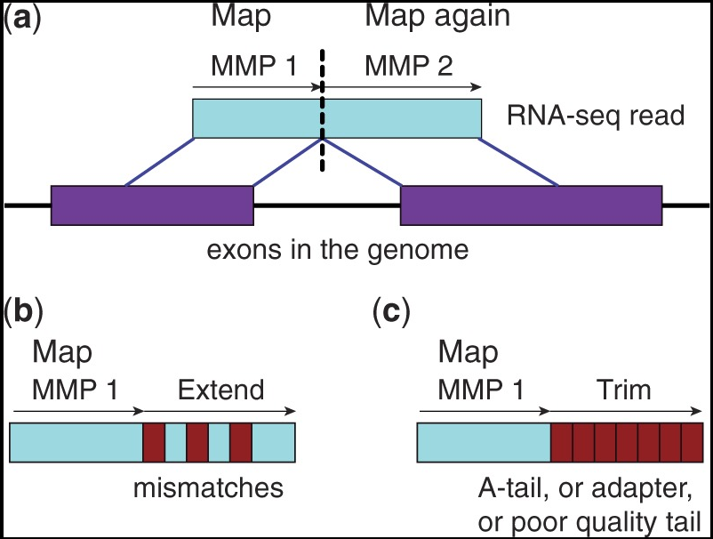

### Alignment

- Alignment to the genome
- Alignment to the transcriptome
  - Rare in the context of true alignment
  - May be valuable where a quality genome does not exist for your organism

### Alignment

- Alignment to the genome
- Alignment to the transcriptome

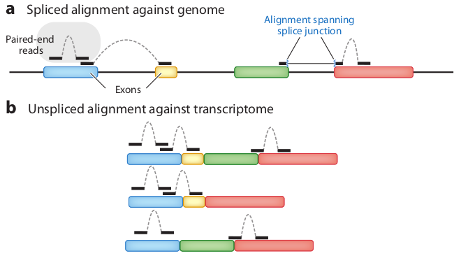

### Counting

Counts represent the number of reads produced by the RNA-Seq experiement that can be assigned to a genomic feature.

They are the measurement that we can use to estimate differential expression.

They can be converted to many different abundance measurements.

### Counting

*Counts to abundance:*

A lot more detail *[here](http://robpatro.com/blog/?p=235)*

**CPM = Counts Per Million**

`CPM = (count * 10e6) / total_reads`

**RPKM = Reads Per Kilobase per Million mapped reads** or **FPKM = Fragments Per Kilobase per Million mapped reads**

`RPKM (or FPKM) = (count * 1e3 * 1e6) / (total_reads * gene_length_in_bp)`

**TPM = Transcript Per Million**

`TPM = A * (1 / sum(A)) * 1e6`

`A = count * 1e3 / gene_length_in_bp`

### Counting

Considerations:

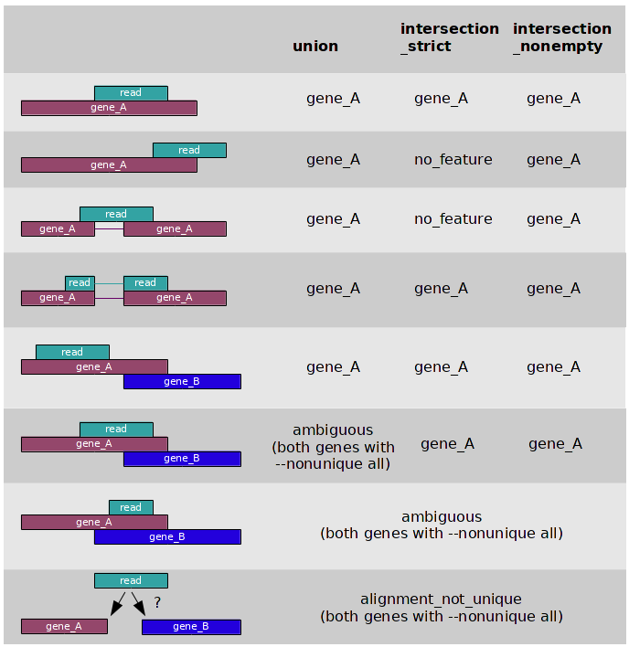

### Counting

Work Around:

[figure not shown]

### Mapping

- Alternative to alignment + counting

### Mapping

- Alternative to alignment
- Useful for quantifying gene expression of known genes and isoforms

### Mapping

- Alternative to alignment
- Useful for quantifying gene expression of known genes and isoforms
- Fast and computationally cheap
- Direct to transcriptome - only as good as your gene models

### Mapping

Tiny cluster for doing mapping

~ 15million reads on one core in 11 minutes

[figure not shown]

### Mapping

Get read assignment to genes/transcripts for free

There is no seperate quantification step

### Mapping

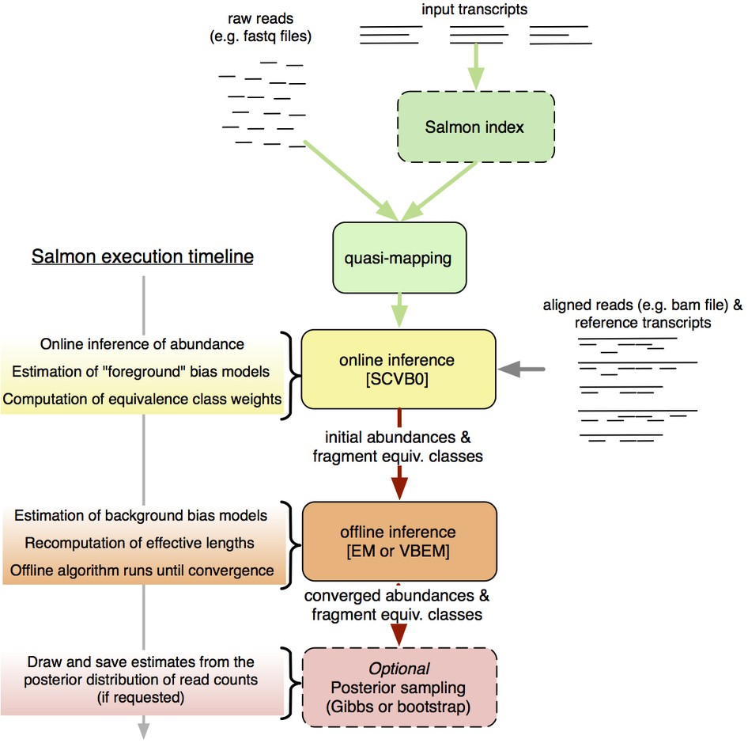

### Mapping

The main tools are salmon and kallisto

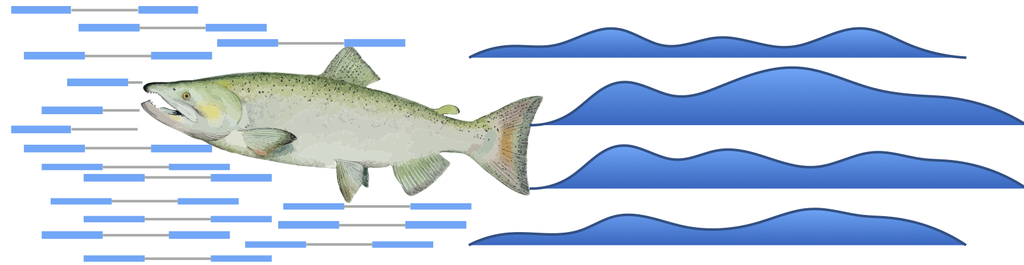

[figure not shown]

### Mapping

- Requires a transcriptome `.fasta` file & preferably a `.gtf` file containing a comprehensive set of genes
  - These produce an index
- Requires reads in the form of `.fastq`
- Outputs a table with Transcript IDs, Counts, Transcript Lengths, and TPM values

### Mapping

- Outputs a table with Transcript IDs, Counts, Transcript Lengths, and TPM values

[output not shown]

The effective length is akin to the regular length of each transcript type, except that it accounts for the fact that not every transcript in the population can produce a fragment of every length starting at every position. Actually, a transcript has an effective length with respect to each possible fragment that maps to it

### Quality Control

Should be done both before and after alignment

AKA on the FASTQ files directly and on the resulting BAMS

### Quality Control

A lot of quality control becomes clearer in the context of other experiments.

[MultiQC](https://multiqc.info/docs/) facilitates this process with plugins to colate [92 different QC tools](https://multiqc.info/#supported-tools):

[figure not shown]

### Quality Control - FASTQ

[*FastQC*](https://www.bioinformatics.babraham.ac.uk/projects/fastqc/)

[figure not shown]

### Quality Control - FASTQ

[*FastQ Screen*](https://www.bioinformatics.babraham.ac.uk/projects/fastq_screen/)

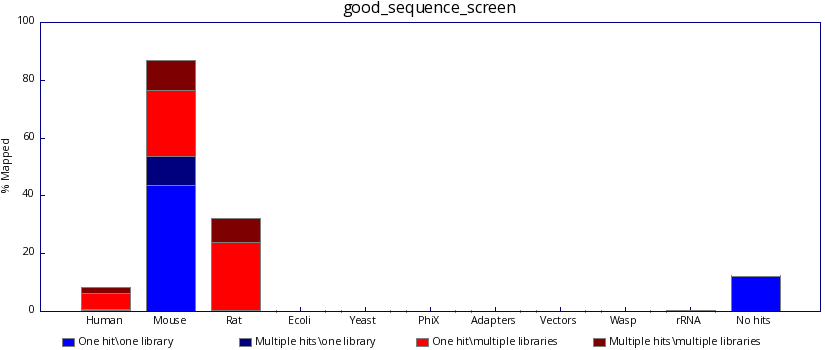

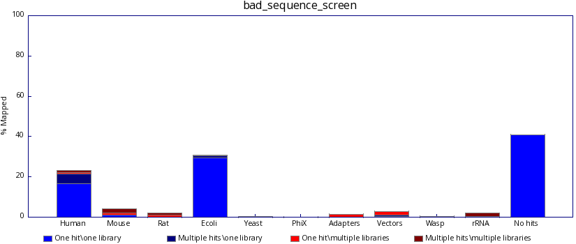

### Quality Control - FASTQ

### Quality Control - BAMs

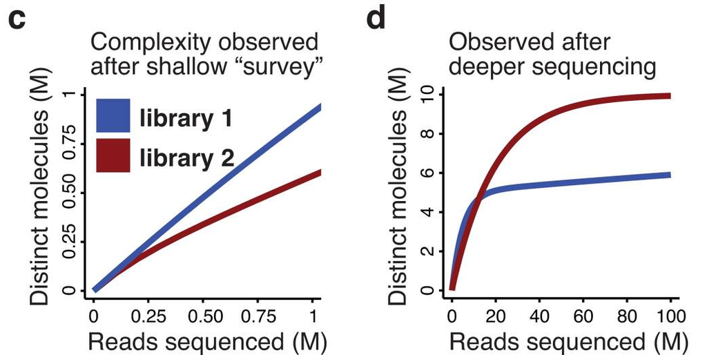

[Preseq](http://smithlabresearch.org/software/preseq/) | [featureCounts](http://bioinf.wehi.edu.au/featureCounts/) | [Picard](https://broadinstitute.github.io/picard/picard-metric-definitions.html#RnaSeqMetrics) | STAR